# NFL 2020 Week 10

MAJ Daniel Baller

## Instructor Group Predictions

This Week's Predictions

Week 10

| Game | Prediction | Winner | Correct | Correct Votes | Correct Percent |
| --- | --- | --- | --- | --- | --- |
| 1 | Tennessee Titans | Indianapolis Colts | No | 0 | 0.0000 |
| 2 | Green Bay Packers | Green Bay Packers | Yes | 18 | 1.0000 |
| 3 | Cleveland Browns | Cleveland Browns | Yes | 17 | 0.9444 |
| 4 | Philadelphia Eagles | New York Giants | No | 3 | 0.1667 |
| 5 | Tampa Bay Buccaneers | Tampa Bay Buccaneers | Yes | 18 | 1.0000 |
| 6 | Detroit Lions | Detroit Lions | Yes | 14 | 0.7778 |
| 7 | Miami Dolphins | Miami Dolphins | Yes | 15 | 0.8333 |
| 8 | Las Vegas Raiders | Las Vegas Raiders | Yes | 18 | 1.0000 |
| 9 | Buffalo Bills | Arizona Cardinals | No | 4 | 0.2222 |
| 10 | Pittsburgh Steelers | Pittsburgh Steelers | Yes | 17 | 0.9444 |
| 11 | Seattle Seahawks | Los Angeles Rams | No | 3 | 0.1667 |
| 12 | New Orleans Saints | New Orleans Saints | Yes | 18 | 1.0000 |
| 13 | Baltimore Ravens | New England Patriots | No | 1 | 0.0556 |
| 14 | Chicago Bears | Minnesota Vikings | No | 5 | 0.2778 |

Our win percentage for the week is 0.5714

Our season win percentage so far is 0.6507

Games picked this season 146

Correct Games this season 95

predictions this week

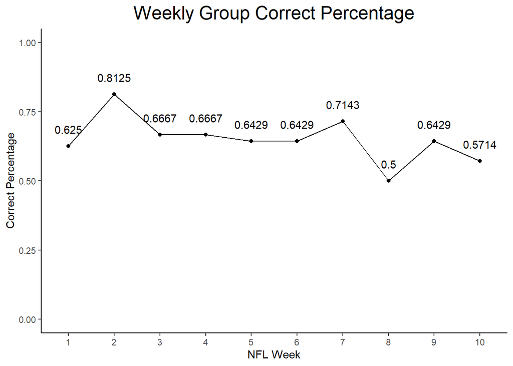

## Individual Predictions

Individual Results

Week 10

Name

Weekly # Correct

Percent

Weeks Picked

Season Percent

Adj Season Percent

Season Trend

Week 1

Week 2

Week 3

Week 4

Week 5

Week 6

Week 7

Week 8

Week 9

Week 10

James Starling

15

12

9

12

10

NA

11

8

10

10

0.7143

9

0.7348

0.6613

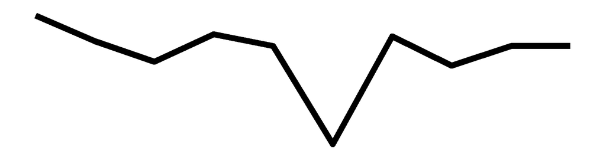

James Pleuss

9

12

10

12

7

8

10

9

9

10

0.7143

10

0.6575

0.6575

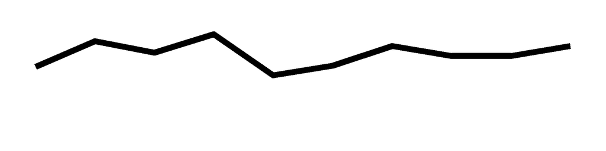

Daniel Baller

11

10

10

9

9

5

8

9

11

10

0.7143

10

0.6301

0.6301

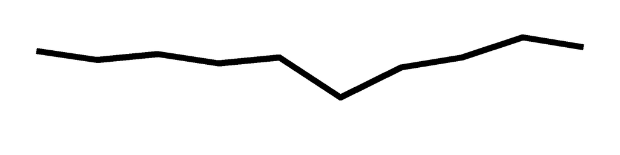

John Kearby

9

11

6

9

9

8

12

6

9

10

0.7143

10

0.6096

0.6096

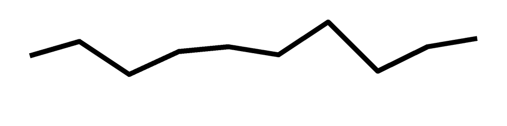

Gabriel Costa

9

12

6

9

10

7

9

7

10

10

0.7143

10

0.6096

0.6096

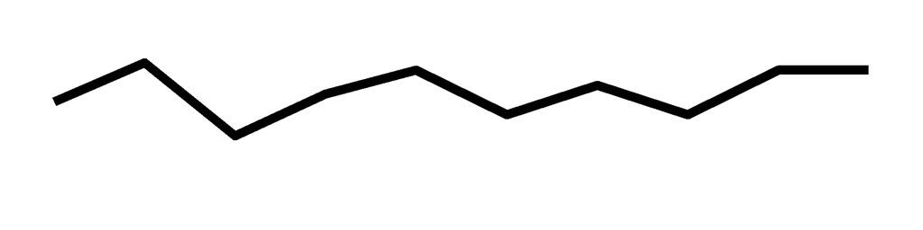

Michael Prokos

9

12

9

8

11

10

9

7

9

9

0.6429

10

0.6370

0.6370

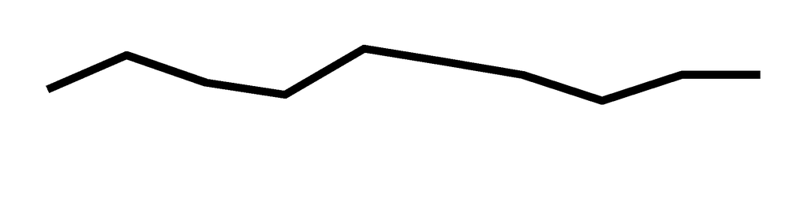

Kevin Cummiskey

13

11

9

9

10

7

9

5

10

9

0.6429

10

0.6301

0.6301

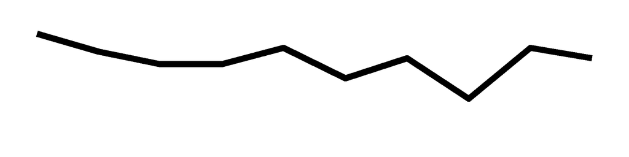

Nicholas Reisweber

9

10

10

8

10

7

8

8

10

9

0.6429

10

0.6096

0.6096

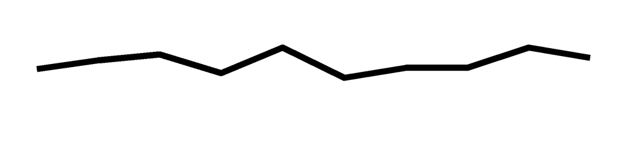

Margaret Wieczorek

11

14

9

9

8

NA

10

8

9

8

0.5714

9

0.6515

0.5864

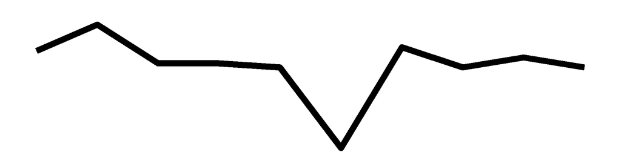

Welvin Lucero

9

11

9

10

NA

NA

11

8

NA

8

0.5714

7

0.6346

0.4442

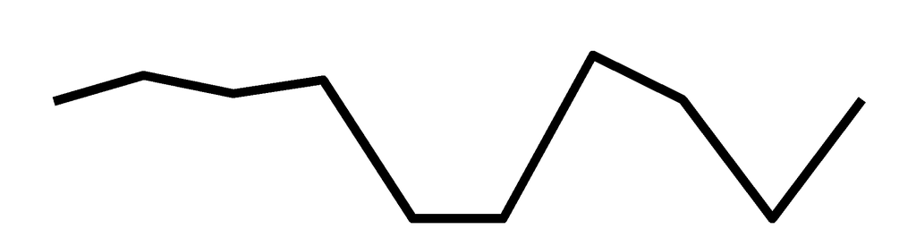

Josephine Cammack

9

11

12

10

9

9

11

7

6

8

0.5714

10

0.6301

0.6301

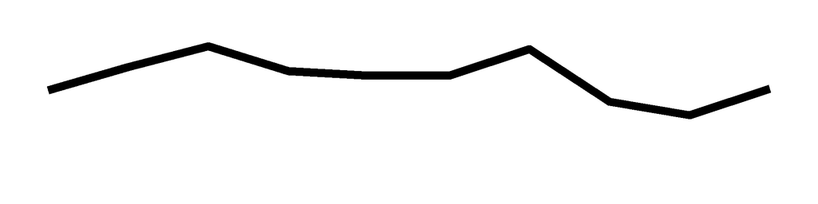

Blake Schwartz

10

9

10

10

10

9

9

6

5

8

0.5714

10

0.5890

0.5890

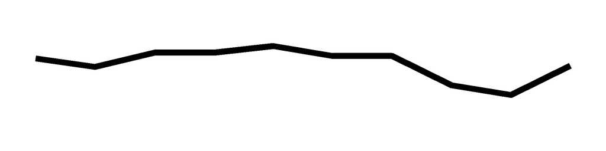

Tina Hartley

9

11

10

8

8

9

9

7

3

8

0.5714

10

0.5616

0.5616

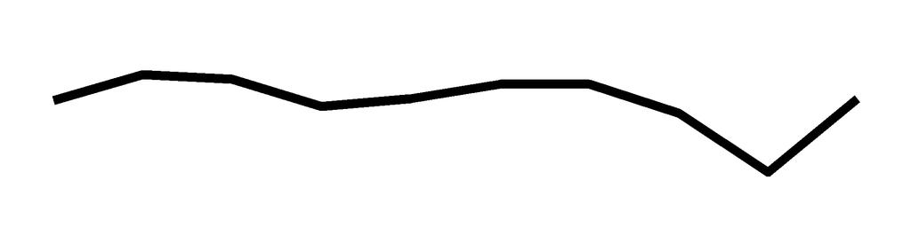

Eric Swenson

4

8

10

9

9

8

9

8

7

8

0.5714

10

0.5479

0.5479

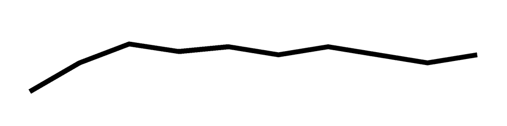

Shane Clark

10

14

9

9

9

9

10

NA

11

7

0.5000

9

0.6667

0.6000

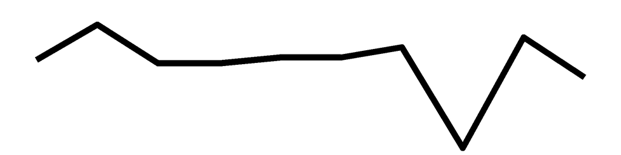

Gregory Minetos

9

14

10

12

8

8

12

7

10

7

0.5000

10

0.6644

0.6644

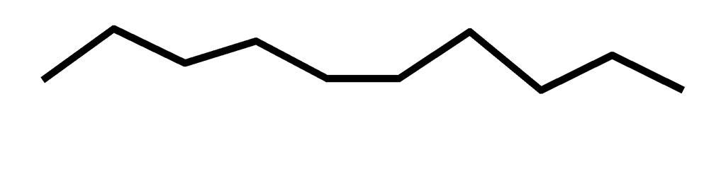

Kevin Quigley

8

8

9

10

10

8

8

6

8

7

0.5000

10

0.5616

0.5616

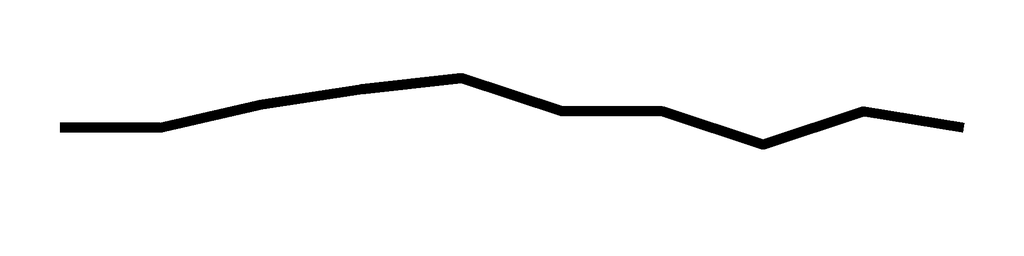

Frank Czerniakowski

7

13

10

9

8

6

9

6

11

5

0.3571

10

0.5753

0.5753

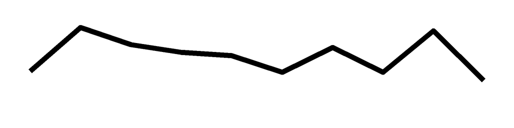

Daniel Richardson

13

11

10

10

8

NA

8

NA

NA

NA

0.0000

6

0.6667

0.4000

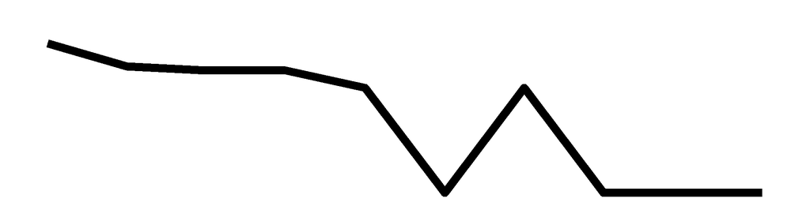

Travis Russell

11

8

8

11

10

10

10

8

NA

NA

0.0000

8

0.6441

0.5153

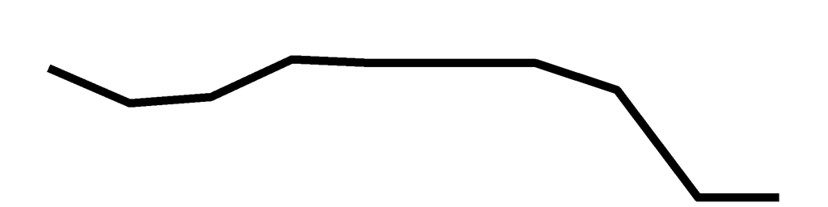

Andrew Lee

9

10

8

NA

NA

NA

NA

NA

NA

NA

0.0000

3

0.5745

0.1724

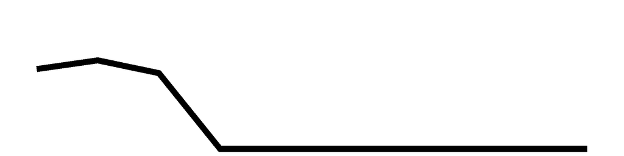

Timothy Moore

10

11

8

9

7

9

7

7

7

NA

0.0000

9

0.5682

0.5114

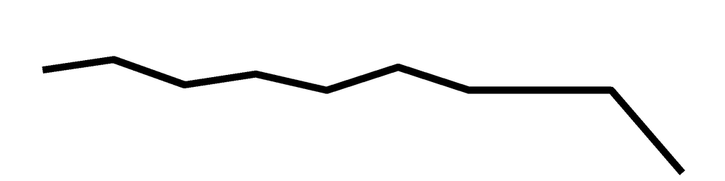

Congrats James Starling for having the best picks this week, with a correct percentage of 0.7143, Congrats James Pleuss for having the best picks this week, with a correct percentage of 0.7143, Congrats Daniel Baller for having the best picks this week, with a correct percentage of 0.7143, Congrats John Kearby for having the best picks this week, with a correct percentage of 0.7143, Congrats Gabriel Costa for having the best picks this week, with a correct percentage of 0.7143

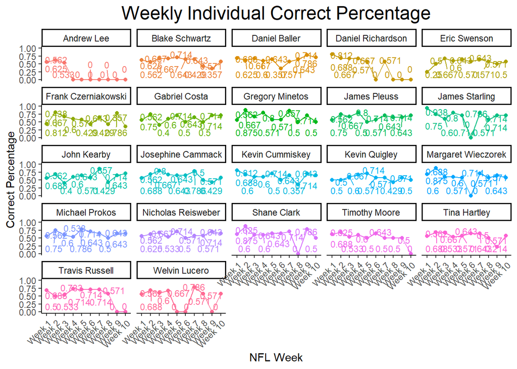

## MA206 Group Predictions

This Week's MA206 Predictions

Week 10

| Game | Prediction | Winner | Correct | Correct Votes | Correct Percent |
| --- | --- | --- | --- | --- | --- |
| 1 | Tennessee Titans | Indianapolis Colts | No | 4 | 0.2667 |
| 2 | Green Bay Packers | Green Bay Packers | Yes | 14 | 0.9333 |
| 3 | Cleveland Browns | Cleveland Browns | Yes | 13 | 0.8667 |
| 4 | Philadelphia Eagles | New York Giants | No | 3 | 0.2000 |
| 5 | Tampa Bay Buccaneers | Tampa Bay Buccaneers | Yes | 14 | 0.9333 |
| 6 | Detroit Lions | Detroit Lions | Yes | 13 | 0.8667 |
| 7 | Miami Dolphins | Miami Dolphins | Yes | 14 | 0.9333 |
| 8 | Las Vegas Raiders | Las Vegas Raiders | Yes | 13 | 0.8667 |
| 9 | Buffalo Bills | Arizona Cardinals | No | 3 | 0.2000 |
| 10 | Pittsburgh Steelers | Pittsburgh Steelers | Yes | 14 | 0.9333 |
| 11 | Seattle Seahawks | Los Angeles Rams | No | 3 | 0.2000 |
| 12 | New Orleans Saints | New Orleans Saints | Yes | 14 | 0.9333 |
| 13 | Baltimore Ravens | New England Patriots | No | 0 | 0.0000 |
| 14 | Chicago Bears | Minnesota Vikings | No | 3 | 0.2000 |

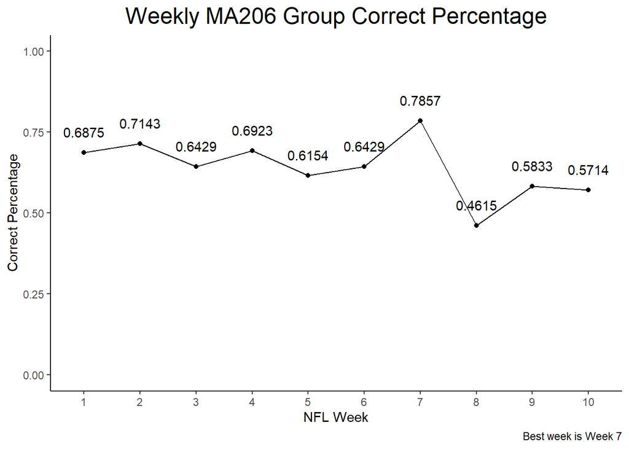